# RNA-seq of AM with and without cryopreservation

Data cleaning

Kim Dill-McFarland, kadm@uw.edu

version February 20, 2023

# Background

The purpose of this workflow is to complete basic data cleaning of metadata and count table. This includes 1) removing low quality libraries, 2) removing outlying libraries, 3) filtering rare genes, and 4) normalizing for RNA composition and voom.

# Setup

Load packages

```r
# Data manipulation and figures
library(tidyverse)
  # Modify ggplot data order within facets
  library(drlib)
  # Plot log scales
  library(scales)
  #Multi-panel figures
  library(patchwork)
  #Custom
  library(BIGpicture)
library(readxl)
#Venn diagrams
library(venn)

# Empirical analysis of digital gene expression data
## Data normalization
library(edgeR)
library(RNAetc)

# Genome reference
# Do not load due to conflicts with tidyverse
# library(biomaRt)

# Print pretty table to knit file
library(knitr)
library(kableExtra)
  options(knitr.kable.NA = '')

#Create 'not in' operator
`%notin%` <- Negate(`%in%`)
```

Set seed

```r
set.seed(927)
```

Make output directories.

```r
dir.create("data_clean/", recursive = TRUE, showWarnings = FALSE)
```

# Customization

Set variable names and cutoffs for this workflow.

```r
#Directory WITHIN project directory that holds raw count, metadata, and gene key
data.dir <- "data_raw"

#Provide file basename
#This will be appended to the start of all file names saved to the disk
basename <- "AM-cryo"

#List main variables of interest
#Will be used to visualize data in tables and plots
#If > 2 variables provided, plots are not colored by variables
vars_of_interest <- c("Mtb","cryo")

# Define cutoffs
#Median CV coverage MAXIMUM
CV.cut <- 1
#Alignment percentage with duplicates MINIMUM
align.cut <- 0.95
#Total sequences MINIMUM
count.cut <- 1E6
```

# Read in and format data

#### Metadata

Includes alignment metrics and total sequences retained during command line cleaning. Filter to samples of interest. Extract additional data from libIDs.

```r
meta <- read_csv("data_raw/cleaning.metrics.csv") %>%
  #remove MACMAC samples
  separate(libID, into = c("libID.no","donorID"), sep="_",
           extra="drop", remove = FALSE) %>%
  mutate(libID.no = as.numeric(libID.no)) %>%
  filter(libID.no >= 69) %>%
  #Add addtl info
  mutate(cell = ifelse(grepl("AM",libID),"AM","MDM"),
         cryo = ifelse(grepl("Cryo",libID) | !grepl("AM",libID),
                       "cryo", "fresh"),
         Mtb = ifelse(grepl("MTB", libID),"mtb","media"),
         treat.hr = ifelse(libID.no >= 75 & libID.no <= 82, "24hr",
                           ifelse(libID.no >= 69 & libID.no <= 74, "6hr", NA)),
         IFN = ifelse(grepl("IFN", libID),
                      gsub("[0-9]{1,2}_C[0-9]{3}_|[0-9]{1,2}_AM[0-9]{2}_Cryo_",
                                            "",libID),"none"),
         batch=2)
```

Add AM18 samples from AM-MDM-TB sequencing.

```r
AM18 <- read_csv("../AM_MDM_TB/data_raw/AM.MDM.data.cleaning.metrics.csv") %>%
  filter(grepl("AM18_AM", sampID)) %>%
  rename(libID=sampID) %>%
  #Add metadata
  mutate(cell="AM", cryo="fresh",
         Mtb=ifelse(grepl("TB",libID),"mtb","media"),
         IFN="none",donorID="AM18",batch=1,libID.no=c(100,101))
meta <- meta %>%
  #Add AM18 from previous run
  full_join(AM18) %>%
  select(libID.no, libID, donorID, cell:batch, everything())
```

[output not shown]

Switch media/mtb labels for libraries 69-74. See `scripts/MTB_identity_check.R` for details.

```r
meta.clean <- meta %>%
  mutate(Mtb = ifelse(libID.no <= 74 & Mtb == "media", "mtb",
                        ifelse(libID.no <= 74 & Mtb == "mtb", "media",
                               Mtb)))
```

#### Counts

Counts of reads in genes, exons only.

```r
counts.raw <- read_tsv("data_raw/AM.MDM.IFN.featurecounts.paired.tsv",
                      skip=1) %>%
  select(-c(Chr:Length))
#Create simplified names list
name.list <- sub("project/results.am/bam_filter_paired/",
                 "", names(counts.raw))
name.list <- sub("_filter_paired.bam",
                 "", name.list)

#Format counts and filter to samples of interest
counts <- counts.raw %>%
  #Rename columns
  setNames(name.list) %>%
  rename(ensembl_gene_id = Geneid) %>%
  select(ensembl_gene_id, all_of(meta.clean$libID[1:14]))
```

Add AM18 sample

```r
AM18.counts <- read_tsv("../AM_MDM_TB/data_raw/AM.MDM.featurecounts.paired.tsv",
                      skip=1) %>%
  select(Geneid, contains("AM18_AM"))
#Create simplified names list
name.list2 <- sub("project1/data/bam_filter_paired/",
                 "", names(AM18.counts))
name.list2 <- sub("_filter_paired.bam",
                 "", name.list2)

#Format counts and add to other data set
counts.all <- AM18.counts %>%
  #Rename columns
  setNames(name.list2) %>%
  rename(ensembl_gene_id = Geneid) %>%
  full_join(counts) %>%
  #remove genes not in both dataset
  filter_all(all_vars(!is.na(.)))
```

## Filter to cyro relevant samples

```r
meta.clean.filter <- meta.clean %>%
  filter(IFN == "none" & cell == "AM") %>%
  filter(is.na(treat.hr) | treat.hr == "6hr")

counts.all.filter <- counts.all %>%
  select(1, all_of(meta.clean.filter$libID))
```

## Summarize samples

Total libraries

| cell | Mtb | cryo | n |
| --- | --- | --- | --- |
| AM | media | cryo | 2 |
| AM | media | fresh | 2 |
| AM | mtb | cryo | 2 |
| AM | mtb | fresh | 2 |

# Data cleaning

## Filter protein coding genes

Load key and filter to pc genes with valid HGNC names.

```r
#Get database
ensembl <- biomaRt::useEnsembl(biomart="ensembl", dataset="hsapiens_gene_ensembl")

#Format gene key
key <- biomaRt::getBM(attributes=c("ensembl_gene_id", "entrezgene_id", "hgnc_symbol",
                                   "gene_biotype", "chromosome_name",
                                   "start_position", "end_position"), mart=ensembl)

key.filter <- key %>%
  #Filter protein coding genes
  filter(gene_biotype == "protein_coding") %>%
  #Filter protein coding genes in count table
  filter(ensembl_gene_id %in% counts.all.filter$ensembl_gene_id) %>%
  #collapse multiannotations.
  group_by(ensembl_gene_id, hgnc_symbol, gene_biotype,
           chromosome_name, start_position, end_position) %>%
  summarise(entrezgene_id = list(unique(entrezgene_id)), .groups = "drop") %>%
  group_by(ensembl_gene_id, entrezgene_id, gene_biotype,
           chromosome_name, start_position, end_position) %>%
  summarise(symbol = list(unique(hgnc_symbol)), .groups = "drop") %>%
  arrange(ensembl_gene_id)
```

Filter count table to protein coding genes.

```r
counts.pc <- counts.all.filter %>%
  filter(ensembl_gene_id %in% key.filter$ensembl_gene_id) %>%
  arrange(ensembl_gene_id)
```

#### Check genes

*all genes in the key are found in the data. And vice versa.*

```
## [1] TRUE
```

## Assess library coverage

#### Median CV coverage vs. mapped duplicate reads

Compare the median coefficient of variation (CV) coverage (`median_cv_coverage`) and percent alignment of reads with duplicates (`mapped_reads_w_dups`). Ideally, you want libraries with LOW median CV coverage and HIGH percent aligned duplicates, indicating low variability in coverage over the length of genes and high coverage across the genome, respectively.

Plot CV coverage vs alignment. Samples outside the cutoff assigned above are labeled with sampID.

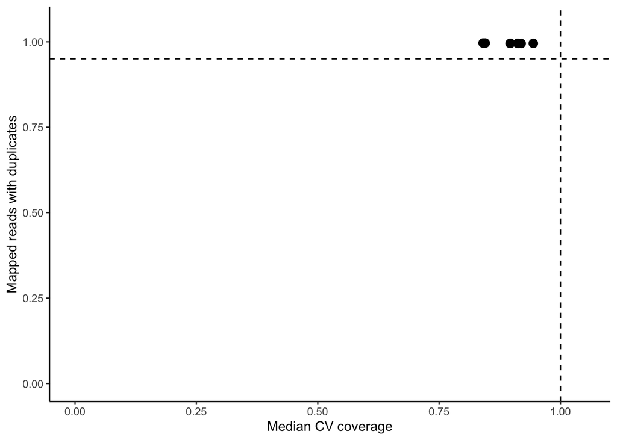

#### Total aligned counts

Assess aligned counts per library. Higher counts indicate high coverage and are preferred.

Plot total counts per library. Libraries outside cutoffs are labeled as “questionable”. The minimum total sequences cutoff set above is indicated by a horizontal line.

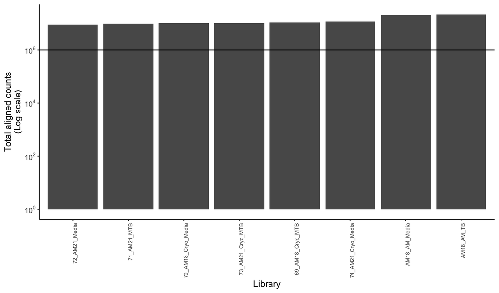

## Assess PCA

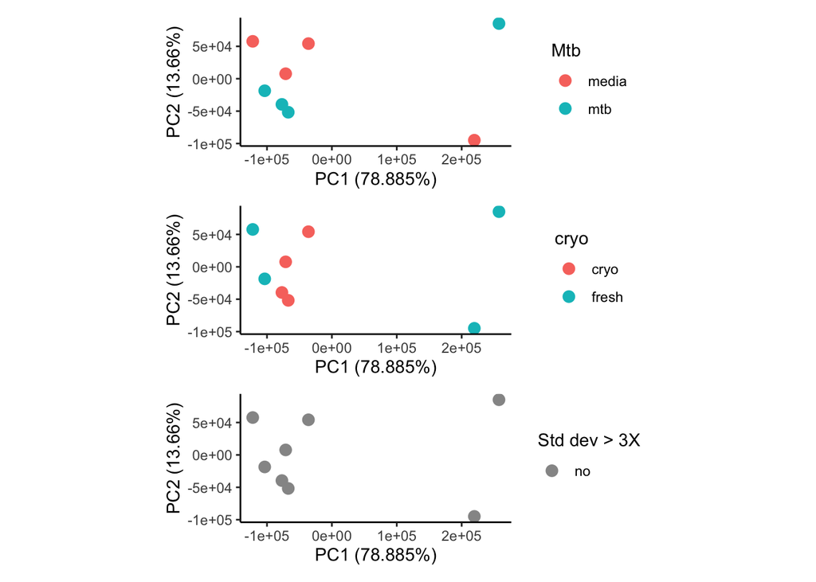

### Filter PCA outliers

There are no outliers in these data.

## Create DGEList object

For use in gene filtering with edgeR

```r
dat.pc <- DGEList(
  #count table. move gene names to column names
  counts=as.matrix(column_to_rownames(counts.pc,
                                      "ensembl_gene_id")),
  #metadata
  samples=meta.clean.filter,
  #keep genes in count table
  genes=key.filter)
```

## Filter rare genes

The raw gene sets contain highly variable, low abundance/rare genes. We retain abundant genes at > 0.1 CPM in at least 2 samples.

```
## 5535 (27.79%) of 19914 genes removed.
```

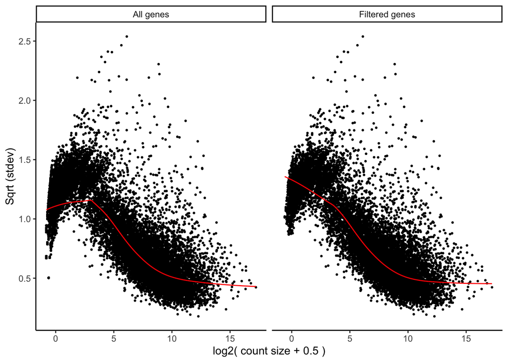

```r
dat.pc.abund <- filter_rare(dat.pc, min.CPM = 0.1, min.sample = 2, plot = TRUE)
```

This removes 5535 (~ 28%) genes. See `results/AM-MDM_rare_genes_removed.csv` for info on genes removed.

## Normalize for RNA composition

Calculate factors to scale library sizes.

```r
dat.pc.abund.norm <- calcNormFactors(dat.pc.abund)
```

## Normalize with voom

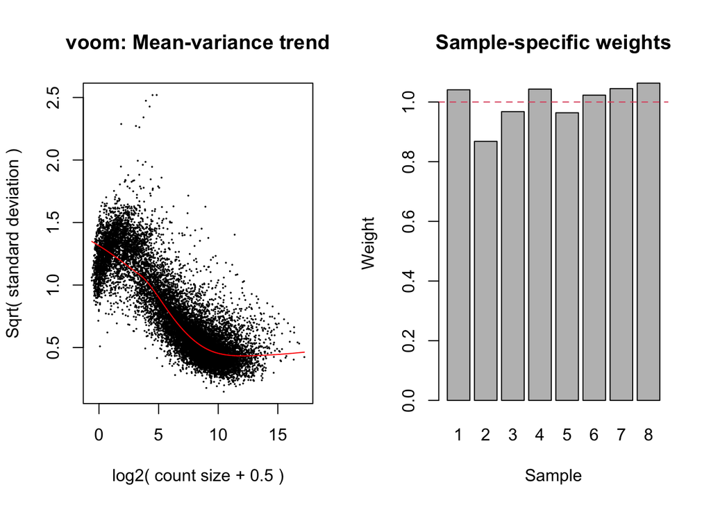

```r
dat.pc.abund.norm.voom <- voomWithQualityWeights(
                          dat.pc.abund.norm,
                          design=model.matrix(~Mtb,
                                 data=dat.pc.abund.norm$samples),
                          plot=TRUE)
```

## PCA final data set

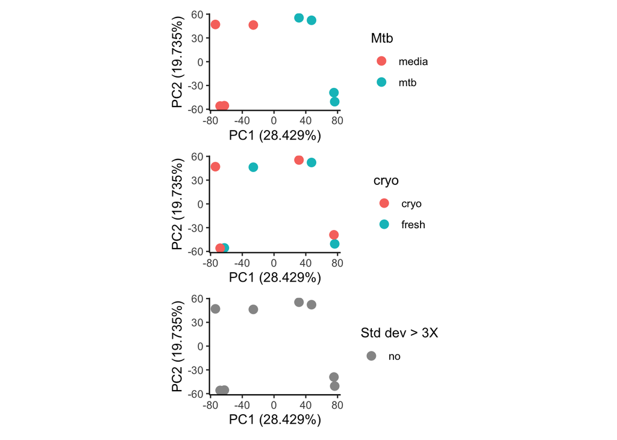

## Summarize cleaning

|  | Removed |
| --- | --- |
| High median CV coverage samples | 0 |
| Low alignment percentage samples | 0 |
| Low total sequences samples | 0 |
| PCA outlier samples | 0 |
| Rare genes | 5535 |

# Save data

Write as RData

```r
#Rename to short form
dat <- dat.pc
dat.voom <- dat.pc.abund.norm.voom

save(dat,
     file=paste("data_clean/", basename, "_count.RData", sep=""))
save(dat.voom,
     file=paste("data_clean/", basename, "_voom.RData", sep=""))
```

Write counts as table.

```r
#Counts table
as.data.frame(dat.pc.abund.norm.voom$E) %>%
  #Add hgnc
  rownames_to_column("ensembl_gene_id") %>%
  left_join(dat.pc.abund.norm.voom$genes, by="ensembl_gene_id") %>%
  select(ensembl_gene_id, symbol, gene_biotype, everything()) %>%
  select(-c(entrezgene_id:end_position)) %>%

write_csv(paste("data_clean/", basename, "_voom.csv", sep=""))
```